# Assignment 3: Sentiment Classification Reflection

# Training Dynamics

## MLP Training

### MLP Training Results

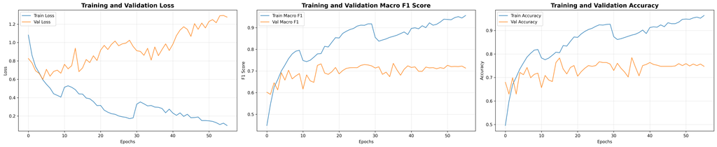

MLP Training Curves

### MLP Confusion Matrix

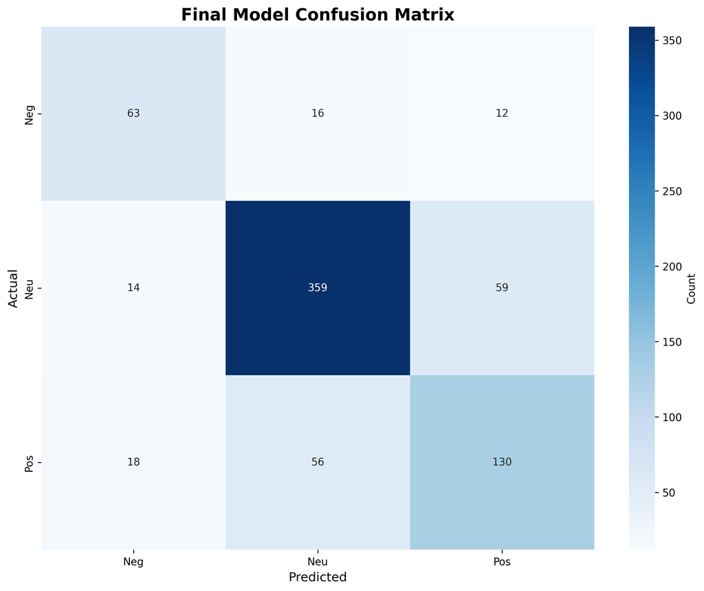

MLP Confusion Matrix

## LSTM Training

Based on the curves of loss, accuracy, and F1, my model showed signs of overfitting. The training loss went down much faster than the validation loss, showing that the model was losing generalizability and overfitting. Again, I could try to implement a stop after the validation loss doesn’t see much improvement/goes up. However it would likely have to happen before 30 epochs. Class weights again helped to affect training stability as the majority of the data lies in neutral, so having class weights helps to push the model to distinguish positive and negative and not just safely pick neutral.

### LSTM Training Results

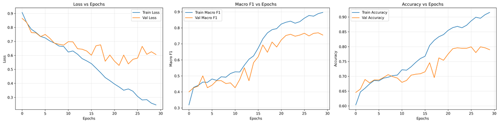

LSTM Training Curves

### LSTM Confusion Matrix

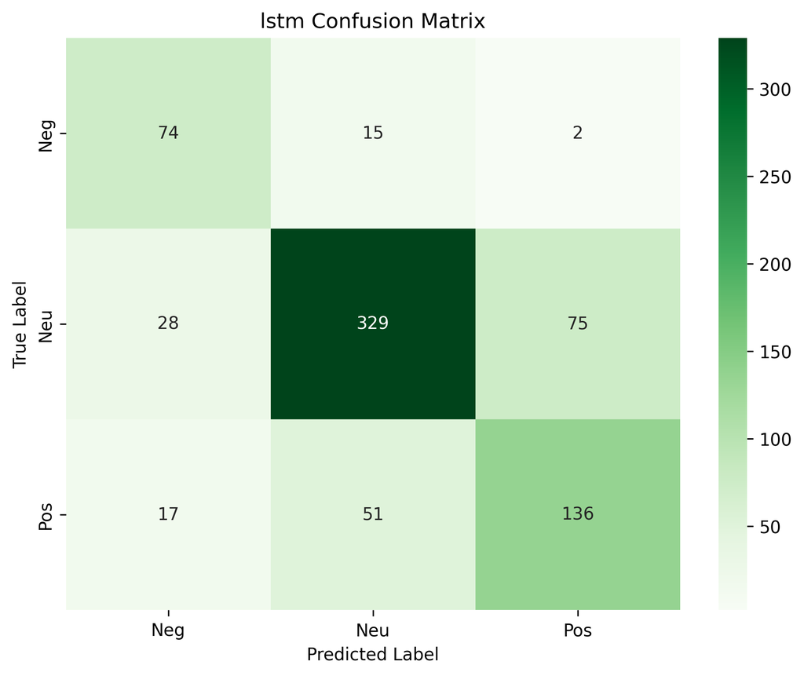

LSTM Confusion Matrix

# Model Performance and Error Analysis

# Cross model comparison

### RNN

#### RNN F1 Learning Curves

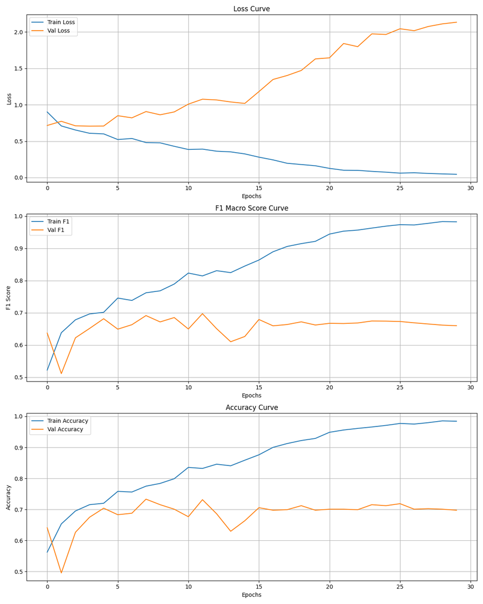

#### RNN Confusion Matrix

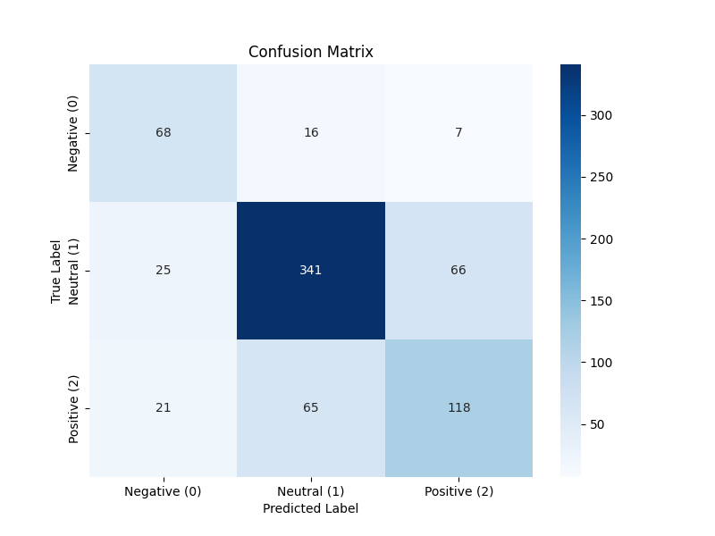

RNN Confusion Matrix

Final Test Accuracy: 0.7111 Test F1 Macro: 0.6919 Test F1 Weighted: 0.7162

Per-class F1 Scores: Negative (0): 0.6968 Neutral (1): 0.7719 Positive (2): 0.6069

### GRU

#### GRU F1 Learning Curves

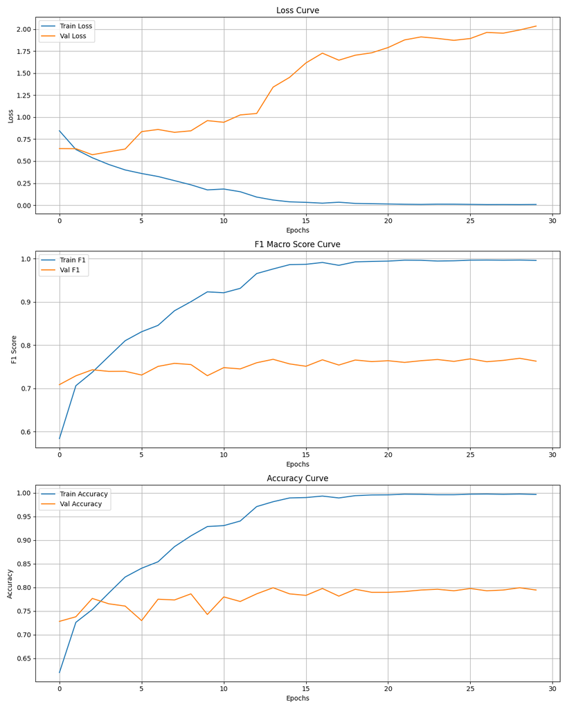

#### GRU Confusion Matrix

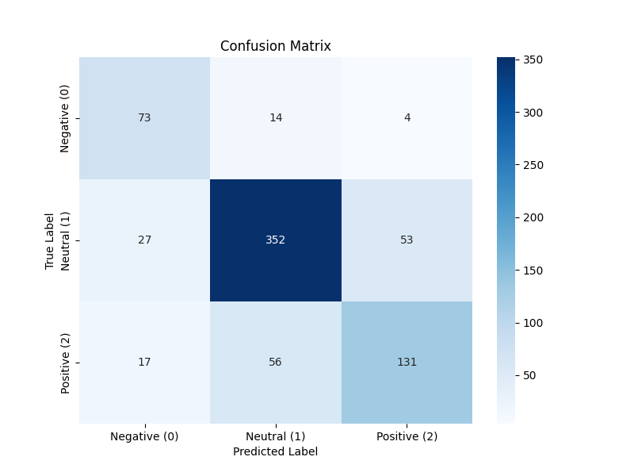

GRU Confusion Matrix

Final Test Accuracy: 0.7510 Test F1 Macro: 0.7254 Test F1 Weighted: 0.7536

Per-class F1 Scores: Negative (0): 0.7037 Neutral (1): 0.8043 Positive (2): 0.6683

### BERT

#### BERT F1 Learning Curves

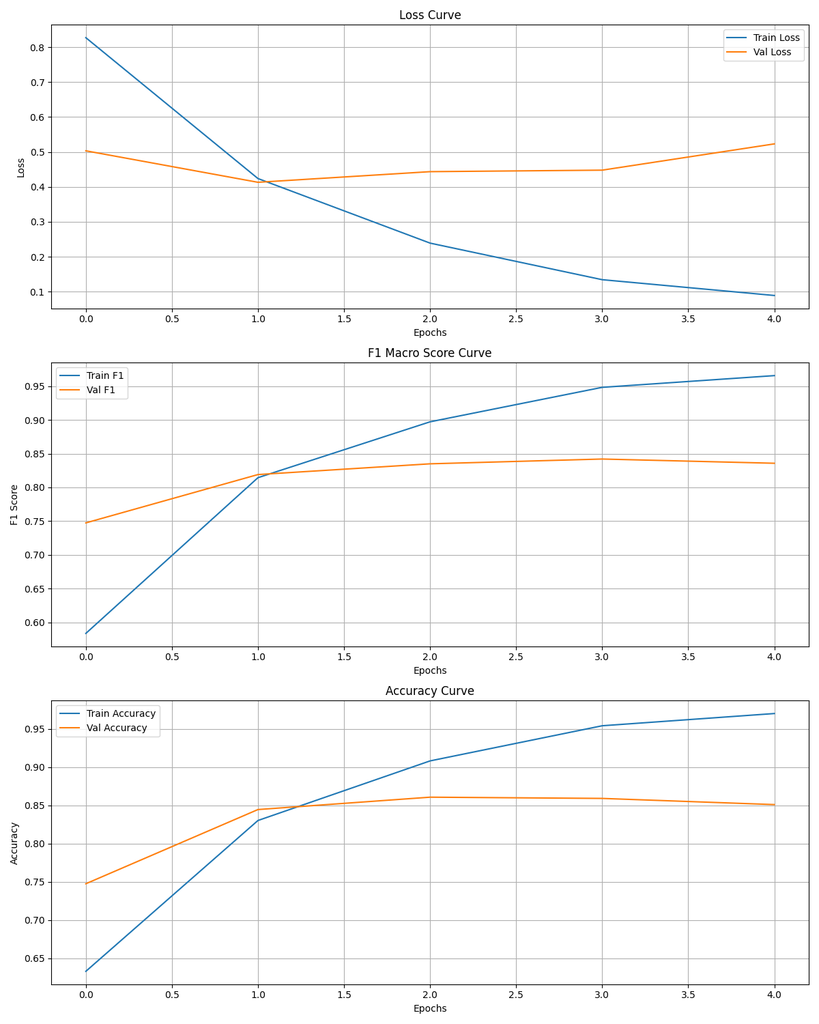

#### BERT Confusion Matrix

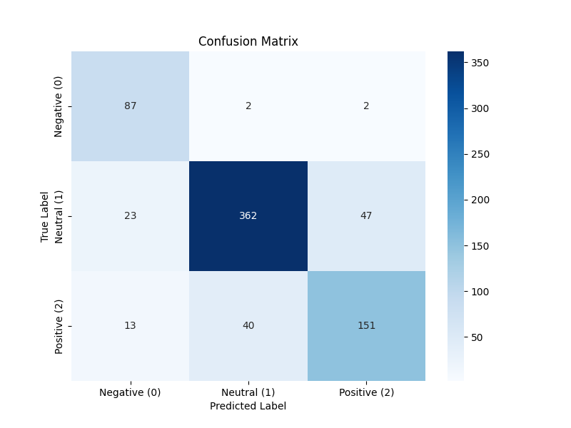

BERT Confusion Matrix

Bert final results

Final Test Accuracy: 0.8294 Test F1 Macro: 0.8204 Test F1 Weighted: 0.8313

Per-class F1 Scores: Negative (0): 0.8360 Neutral (1): 0.8630 Positive (2): 0.7621

### GPT

#### GPT F1 Learning Curves

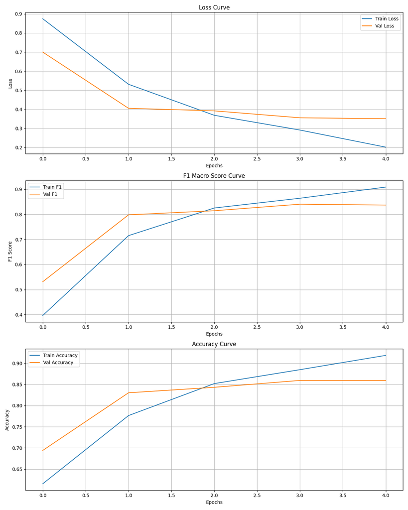

#### GPT Confusion Matrix

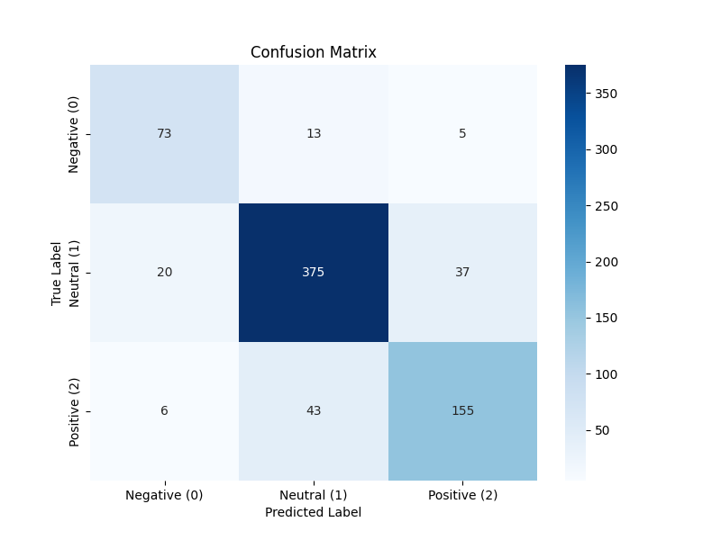

GPT Confusion Matrix

Final Test Accuracy: 0.8116 Test F1 Macro: 0.7717 Test F1 Weighted: 0.8054

Per-class F1 Scores: Negative (0): 0.7514 Neutral (1): 0.8690 Positive (2): 0.6947

The fact that MLP relied on Fasttext embeddings compared to sequence based models caused it to mostly perform worse. While most fo the models saw overfitting, the end result of F1 on validation data is better for the sequence based model. This advantage for sequence processing models like comes from the fact the context of financial data is much different from regular context that the fasttext likely takes from, thus causing it to struggle to understand what the data means. On the other hand, learning from sequences allows a better distinguishing of sentiment in context, thus allowing said models to perform much better. The fine tuned LLMs did outperform all of the classical baseline models. In terms of pretraining, these LLMS have been trained on a much larger database and have seen lots of context before they start learning the task while the classical models have to build up from not understanding anything. As for contextual representations, the usage of self attention in the LLMs allows the LLMS to understand context throughout the entire sentence easily while the classical models struggle to retain longer distance contexts. Thus the rankings are as follows: 1. BERT (Test F1 Macro: 0.8204, Test F1 Weighted: 0.8313) 2. GPT (Test F1 Macro: 0.7717, Test F1 Weighted: 0.8054) 3. GRU (Test F1 Macro: 0.7254, Test F1 Weighted: 0.7536) 4. LSTM (Macro F1 Score: 0.7242) 5. MLP (FINAL TEST MACRO F1 SCORE: 0.6998) 6. RNN (Test F1 Macro: 0.6919, Test F1 Weighted: 0.7162)

The first two models work the best thanks to their ability to use self attention, allowing parallelism and long range interaction of words in O(1) along with having strong contextual embeddings in comaprison to the mostly static embeddings of RNN, LSTM, and MLP. As for why GRU is better than LSTM, it is thanks to the gating within GRU allowing it to protect information long term. Finally, RNN as it can struggle with the vanishing gradient problem struggling to learn across a sentence, and MLP is just barely above RNN as it fails to understand word order and thus struggles.

## AI Use Disclosure (Required)

If you used any AI-enabled tools (e.g., ChatGPT, GitHub Copilot, Claude, or other LLM assistants) while working on this assignment, you must disclose that use here. The goal is transparency-not punishment.

In your disclosure, briefly include: - **Tool(s) used:** (name + version if known) - **How you used them:** (e.g., concept explanation, debugging, drafting code, rewriting text) - **What you verified yourself:** (e.g., reran the notebook, checked outputs/plots, checked shapes, read documentation) - **What you did *not* use AI for (if applicable):** (optional)

You are responsible for the correctness of your submission, even if AI suggested code or explanations.

#### Write your disclosure here.

Gemini Flash 1.5 and Claude Sonnet 4.5

I used them to help me draft the code for the lstm and mlp models and their graphs, while also making sure that my explanations and reasoning for the performance of each model in my write up was correct.

I went through the architecture of each model and made sure they were consistent with the techniques introduced in the slides and example documentation found online.